# Исследование конкурентных отношений беломорских мидий Mytilus edulis и M. trossulus

Андрей Шилонцев

2023-12-20

# Введение

Следуя принципу конкурентного исключения, при совместном поселении двух конкурирующих видов один из них исчезает (Gause 2019). Исключение менее конкурентоспособного вида подразумевает плотностно-зависимое увеличение смертности. Вместе с тем экспериментальных исследований этого процесса в отношении совместных поселений *M. edulis* и *M. trossulus* до сих пор не проводилось. Мы провели эту работу, чтобы доказать, наличие конкурентных отношений между беломорскими *M. edulis.* и *M. trossulus*.

# Материалы и методы

### Подготовка экспериментального материала

Мидии для эксперимента собирали в двух поселениях мидий. Первая точка сбора находилась на мидиевой банке, расположенной на литорали о. Б. Ломнишный (66.97496 N, 32.62013 E). Вторая точка сбора находилась литорали Северной губв о. Ряжкова (66.97496 N, 32.62013 E), где мидий собирали с таломов фукоидов.По результатам пилотных обследований на первой точке абсолютное большинство мидий относится к *M.edulis*, а на второй - к *M.trossulus*. Для эксперимента отбирали мидий 15-40 мм длинной. На правую створку каждой мидии взятой из первой точки мы ставили метку в виде капли цианакрилатного клея с напыленным на него синим порошком-колеровщиком для акриловых красок. На левую створку мидий, собранных из второй точки, наносили аналогичную метку, но желтого цвета. По эти меткам далее производилось различение моллюсков. В данной работе мы не проводили тонкой дифференцировки мидий по их морфотипам, как это делалось в предыдущих работах (Khaitov and Lentsman 2016; Нужин, n.d.), но считали, что из первой точки собраны большей частью *M.edulis* а из второй - *M.trossulus*.

### Постановка эксперимента

Мидий рассадили в контейнеры (200х100х96мм), которые были разбиты на три категории по соотношению численностей двух видов: *MT-dominated* (cоотношение *M.trossulus*:*M.edulis* 4:1), *Mixed* (1:1) и *ME-dominated* (1:4).

Таблица 1. Содержимое экспериментальных садков.

| Тип садка | Доля *M.trossulus* | Колличество | Количество повторностей |
| --- | --- | --- | --- |
| MT-dominated | 0.8 | 20 | 3 |
| MT-dominated | 0.8 | 60 | 3 |
| MT-dominated | 0.8 | 120 | 3 |
| Mixed | 0.5 | 20 | 2 |
| Mixed | 0.5 | 60 | 2 |
| Mixed | 0.5 | 120 | 3 |
| ME-dominated | 0.2 | 20 | 3 |
| ME-dominated | 0.2 | 60 | 3 |
| ME-dominated | 0.2 | 120 | 3 |

Примечание: Во время экспозиции несколько садков было утрачено.

Таким образом, схема нашего эксперимента подразумевает три группы контейнеров: *MT-dominated* (контейнеры, где численность мидий *M.trossulus* превышала численность мидий *M.edulis*), *ME-dominated* (контейнеры, где численность *M.edulis* превышала численность мидий *M.trossulus*), и *Mixed* (контейнеры, где численность мидий двух видов примерно равна). В каждом типе контейнеров был спланирован градиент плотности поселения моллюсков: от разреженных (20 особей на садок) до очень плотных (120 особей).

Мы прикрепили контейнеры с помощью шурупов к 3 доскам к нижней части которых были прикреплены утяжелители (кирпичи), перемешав при этом все типы контейнеров в случайном порядке. Затем эти конструкции были опущены в сублитораль на глубину около 1.5 м во время малой воды. Эксперимент был поставлен 3 июня 2023 г. в точке с засеченными координатами 66.9753 N, 32.6265 в районе о. Б. Ломнишный.

### Обработка материала

Мы сняли эксперимент 15 августа, выйдя на точку по координатам. Конструкции были транспортированы в лабораторию, где из садков были извлечены живые моллюски и раковины погибших особей. По меткам, обнаруженным на раковинах мы относили к тем или иным видам.

Живых мидий сварили, и удалили мягкие ткани. После этого раковины высушили. Раковины мертвых моллюсков после отмывки от ила высушили. Далее у живых моллюсков мы измеряли длину раковины с точностью до 1 мм с помощью электронного штангенциркуля. У мертвых моллюсков мы измеряли только те створки, на которых была нанесена метка. У небольшого числа мертвых особей (17.16%) размер не определяли так как раковины были повреждены.

### Статистическая обработка

Вся статистическая обработка проводилась с помощью функций языка статистического программирования R (R Core Team 2023).

Каждый контейнер был отнесен к одному из трех типов: *MT-dominated*, *ME-dominated*, *Mixed*. Тип контейнера далее рассматривался в качестве дискретного предиктора в линейной модели. В эту модель также в качестве предикторов были включены численность живых моллюсков, обнаруженных в конце эксперимента (эту величину мы рассматривали в качестве оценки плотности поселения мидий в контейнере), размер мидии и все возможные взаимодействия между тремя предикторами. Мидий, которые были мертвы в конце эксперимента, были маркированы как единица, а живые, как ноль. Далее этот ряд рассматаривался как бинарная зависмая переменная в линейной модели, основанной на биномиальном распределении. Таким образом, эта модель оценивала вероятность мидии оказаться мертвой в зависимости от того в каком типе садка она находилась, какова была плотность поселения, какой она имела размер и к какому виду она предположительно относилась.  
Описаннаую выше модель мы подвергли упрощению согласно алгоритму пошагового обратного отбора (backwards selection). Оптимальной считалось модель с меньшим показателем информационного критерия Акаике (AIC).

Статистическую значимость отличия угловых коэффициентов от нуля и значимость различий между градациями дискретного фактора оценивали с помощью функции emtrends() из пакета “emmeans”(Lenth 2023).

# Результаты

В таблице 2 представленны оценки параметров финальной модели. Из приведённых данных видно, что значимыми оказываются парные взаимодействия некоторых предикторов. Это означает, что в разных типах садков связь смертности с плотностью поселения выглядит по разному. Кроме того видно, что смертность зависит и от типа садков и от плотности поселения и от размера. Значимой так же оказалась связь смертности с размером. При том коэффициент регрессии отрицателен, следовательно чем больше мидия, тем меньше у нёё шанс погибнуть.

Таблица 2. Оценки параметров финальной модели (прощедшей пошаговый обратный отбор)

| term | estimate | std.error | statistic | p.value |
| --- | --- | --- | --- | --- |
| (Intercept) | 1.3991241 | 1.5258856 | 0.916926 | 0.3591814 |
| SpeciesMT | 1.4499962 | 0.1888357 | 7.678611 | 0.0000000 |
| N | -0.0466793 | 0.0169106 | -2.760361 | 0.0057738 |
| typeMixed | -2.1625382 | 0.6154605 | -3.513691 | 0.0004419 |
| typeMT-dominated | -1.1159008 | 0.5287012 | -2.110645 | 0.0348028 |
| L | -0.1258086 | 0.0515451 | -2.440746 | 0.0146569 |
| N:typeMixed | 0.0195261 | 0.0064734 | 3.016376 | 0.0025582 |
| N:typeMT-dominated | 0.0092601 | 0.0061891 | 1.496204 | 0.1346004 |
| N:L | 0.0015234 | 0.0005795 | 2.628769 | 0.0085695 |

На рис. 1 представденна визуализация финальной модели. Из преиведённх данных видно, что во всех контейнерах сертность *M. trossulus* выше, чем *M. edulis*. Однако, оценка значимости угловых коэффициентов (таблица 3) показала, что в контейнерах типа *ME-dominated* и *MT-dominated* значимое отличие угловых коэффициентов от нуля нет, но в типе *Mixed* смертность значимо увеличивается по мере возрастания плотности того и другого вида.

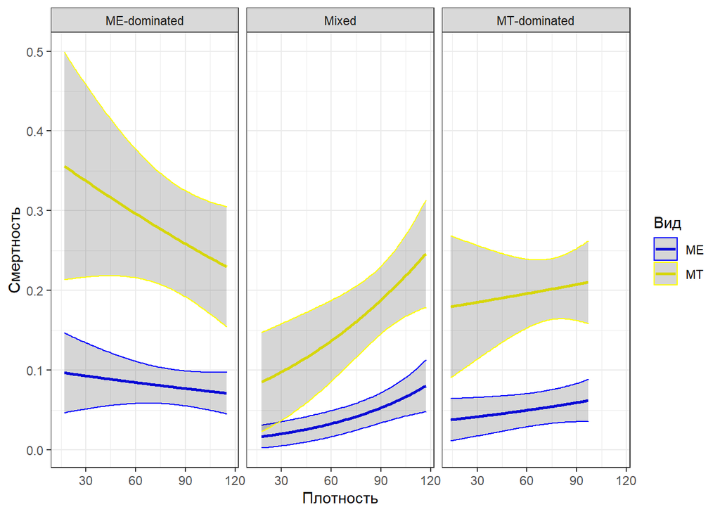

Рисунок 1. Зависимость вероятности гибели миди разных видов от типа садка и плотности поселения (значение размера мидии взято, как среднее)

Таблица 3. Оценка значимости угловых коэффициентов линии регресси для разных видов мидий в разных типах контейнеров.

| type | Species | N.trend | std.error | statistic | p.value |
| --- | --- | --- | --- | --- | --- |
| ME-dominated | ME | -0.0049433 | 0.0039152 | -1.2625810 | 0.2067398 |
| Mixed | ME | 0.0145828 | 0.0050991 | 2.8598560 | 0.0042383 |
| MT-dominated | ME | 0.0043168 | 0.0047113 | 0.9162577 | 0.3595318 |
| ME-dominated | MT | -0.0049433 | 0.0039152 | -1.2625810 | 0.2067398 |
| Mixed | MT | 0.0145828 | 0.0050991 | 2.8598560 | 0.0042383 |
| MT-dominated | MT | 0.0043168 | 0.0047113 | 0.9162577 | 0.3595318 |

# Обсуждение результатов

Главный результат нашего исследования - появление прямомпропорциональной зависимости смертности от плотности, которая появляется в поселениях с равным количеством *M. edulis* и *M. trossulus*. Мы считаем, что это происходит из-за того, что в контейнерах группы Mixed активизируется конкуренция между *M. edulis* и *M. trossulus*. Почему это происходит, с увернностью сказать пока что нельзя.

Brown, CH. 1952. “Some Structural Proteins of Mytilus Edulis.” *Journal of Cell Science* 3 (24): 487–502.

Gause, George Francis. 2019. *The Struggle for Existence: A Classic of Mathematical Biology and Ecology*. Courier Dover Publications.

Katolikova, Marina, Vadim Khaitov, Risto Väinölä, Michael Gantsevich, and Petr Strelkov. 2016. “Genetic, Ecological and Morphological Distinctness of the Blue Mussels Mytilus Trossulus Gould and m. Edulis l. In the White Sea.” *PLoS One* 11 (4): e0152963.

Khaitov, Vadim M, and Natalia V Lentsman. 2016. “The Cycle of Mussels: Long-Term Dynamics of Mussel Beds on Intertidal Soft Bottoms at the White Sea.” *Hydrobiologia* 781: 161–80.

Koehn, Richard K. 1991. “The Genetics and Taxonomy of Species in the Genus Mytilus.” *Aquaculture* 94 (2-3): 125–45.

Lenth, Russell V. 2023. *Emmeans: Estimated Marginal Means, Aka Least-Squares Means*. https://CRAN.R-project.org/package=emmeans.

R Core Team. 2023. *R: A Language and Environment for Statistical Computing*. Vienna, Austria: R Foundation for Statistical Computing. https://www.R-project.org/.

Tamarin, Arnold, Pathicia Lewis, and Joan Askey. 1976. “The Structure and Formation of the Byssus Attachment Plaque in Mytilus.” *Journal of Morphology* 149 (2): 199–221.

Väinölä, Risto, and Petr Strelkov. 2011. “Mytilus Trossulus in Northern Europe.” *Marine Biology* 158: 817–33.

Нужин, Илья. n.d. “Избирательность Морских Звезд Asterias Rubens При Нападении На Мидий Mytilus Edulis и Mytilus Trossulus в Кандалакшском Заливе Белого Моря.”

Федяков, Вячеслав Викторович. 1986. *Закономерности Распределения Моллюсков Белого Моря*. Akademija nauk SSSR Zoologicheskij Institut.

Шалагаева, М. 2018. “Биссусные Прикрепления Mytilus Edulis Linnaeus, 1758 и m. Trossulus Gould, 1850: Механизм Подавления Конкурента.” *Работа Депонирована в Библиотеке Лаборатории Экологии Морского Бентоса (Гидробиологии)*.

Шеламова, В. 2022. “Механизм Конкуренции Мидий Mytilus Edulis Linnaeus, 1758иM. Trossulus Gould, 1850.”